# Independent Identically Distributed Coefficients

Benjamin Christoffersen

2019-03-04

## Introduction

We will simulate and estimate with independent identically distributed coefficients in this example using the particle filter and smoother. For details see this vignette which can also be found by calling `vignette("Particle_filtering", package = "dynamichazard")`. The models we are going to simulate from and estimate are of the form

$$\begin{split}
y_{it} &\sim g(\cdot\vert\eta_{it}) & \\
\vec{\eta}_t &= X_t\vec{\alpha}_t + Z_t\vec{\beta} \\
\vec{\alpha}_t &= \vec{\epsilon}_t &
\quad \vec{\epsilon}_t \sim N(\vec{0}, Q) \\
& & \quad \vec{\alpha}_0 \sim N(\vec{a}_0, Q_0)
\end{split}, \qquad
\begin{array}{l} i = 1, \dots, n_t \\ t = 1, \dots, d \end{array}$$

where the $y_{it}$’s are binary event indicators for individual $i$ at time $t$. It is one if individual $i$ dies at in the time period $(t - 1, t]$.  
$X_t$ and $Z_t$ are covariates and $\vec{\alpha}_0,\dots,\vec{\alpha}_d$ are the latent states. The probability that $y_{it}$ is one conditional on no prior event ($y_{ij} = 0$ for $j = 0,\dots, t - 1$) is the inverse logit function of $\eta_{it}$. Thus, the model is related to a so-called conditional logistic regression. The difference is that we have a distributional assumption about the intercept and we allow some of the other coefficients to vary. The true values are

$$Q = \begin{pmatrix}.75^2 & -.4 \cdot .75^2 \\ -.4 \cdot .75^2 & .75^2 \end{pmatrix}, \quad
\vec{\beta} = (-4, -2)^\top,$$

where we set $X_t = Z_t$ so the random coefficients have a non-zero mean. The unknown parameters to be estimated is $Q$. We are going the estimate a more general model of the form

$$\begin{split}
y_{it} &\sim g(\cdot\vert\eta_{it}) & \\
\vec{\eta}_t &= X_t\vec{\alpha}_t + Z_t\vec{\beta} \\
\vec{\alpha}_t &= F\vec{\alpha}_{t - 1} + \vec{\epsilon}_t &
\quad \vec{\epsilon}_t \sim N(\vec{0}, Q) \\
& & \quad \vec{\alpha}_0 \sim N(\vec{a}_0, Q_0)
\end{split}, \qquad
\begin{array}{l} i = 1, \dots, n_t \\ t = 1, \dots, d \end{array}$$

where $F$ is a $2\times 2$ matrix to be estimated. This example is run on the git branch “devel” with ID “789b7e9”. The code can be found on the Github site for the package. All functions which assignments are not shown and are not in the `dynamichazard` package can be found on the Github site.

## Simulation

We start by simulating the data. Feel free to skip this part as the specifications are given above. First we assign the parameters for the simulation

```r
n_obs     <- 1000L
n_periods <- 100L

Qmat <- matrix(c(.75^2, -.4 * .75^2, -.4 * .75^2, .75^2), 2)
beta <- c(-4, -2)
```

`get_Q_0` is a function to get the covariance matrix for the invariant distribution. Then we simulate and plot the latent states

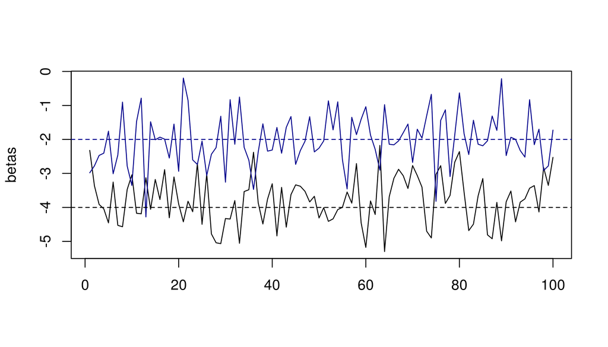

```r
set.seed(54432125)
betas <- matrix(rnorm(n_periods * 2), ncol = 2) %*% chol(Qmat)
betas <- t(t(betas) + beta)

# plot of latent variables
cols <- c("black", "darkblue")
matplot(betas, type = "l", lty = 1, col = cols)
for(i in 1:2)
  abline(h = beta[i], lty = 2, col = cols[i])
```

We simulate the observations as follows

```r
df <- replicate(n_obs, {
  # left-censoring
  tstart <- max(0L, sample.int((n_periods - 1L) * 2L, 1) - n_periods + 1L)

  # covariates
  x <- runif(1, 0, 2)
  covars <- c(1, x)

  # outcome (stop time and event indicator)
  y <- FALSE
  for(tstop in (tstart + 1L):n_periods){
    inv_logit <- 1 / (1 + exp(-covars %*% betas[tstop, ]))
    if(inv_logit > runif(1)){
      y <- TRUE
      break
    }
  }

  c(tstart = tstart, tstop = tstop, x = x, y = y)
})
df <- data.frame(t(df))
head(df, 10)
```

```
##    tstart tstop       x y
## 1      67   100 0.42039 0
## 2      56    82 0.95917 1
## 3      99   100 1.25064 0
## 4       7    75 0.06243 1
## 5       0    80 1.34301 1
## 6      66   100 1.71079 0
## 7       0     2 0.35178 1
## 8       0     1 0.02300 1
## 9       0   100 1.60148 0
## 10     61   100 1.94595 0
```

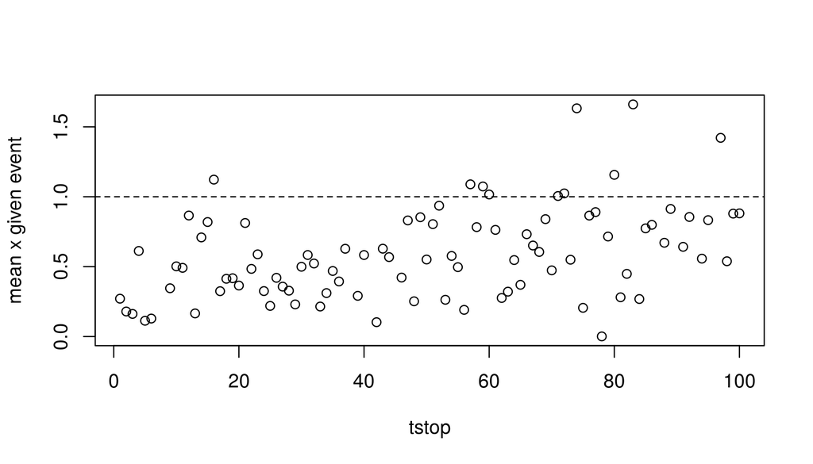

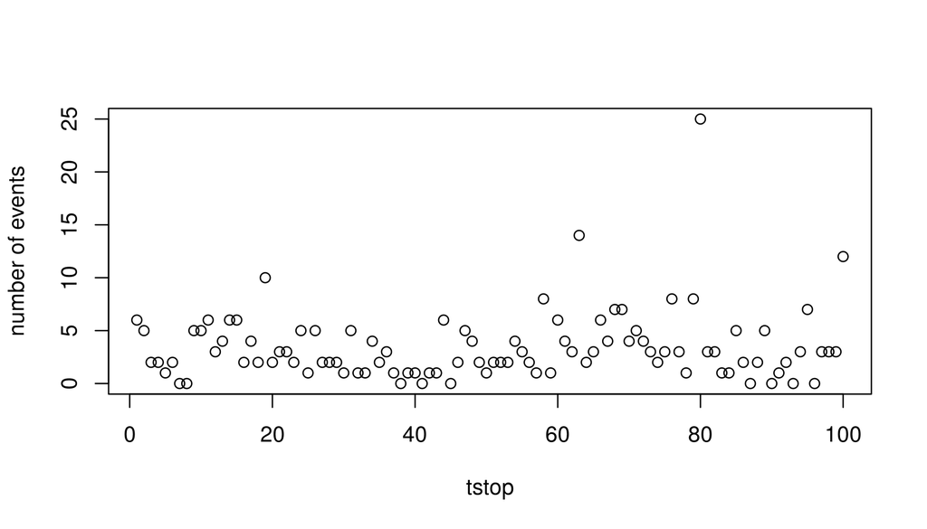

```r
local({
  tmp <- aggregate(x ~ tstop, subset(df, y == 1), mean)
  plot(tmp$tstop, tmp$x, xlab = "tstop", ylab = "mean x given event")
  abline(h = 1, lty = 2)

  df$tmp <- factor(df$tstop, 1:n_periods)
  n_events <- with(subset(df, y == 1),
                   tapply(tmp, tmp, length, default = 0))
  plot(as.integer(names(n_events)), n_events, xlab = "tstop",
       ylab = "number of events", ylim = )
})
```

We left-censor the observations since we otherwise may end up with a low number of observations towards the end.

## lme4::glmer

We start by estimating “the correct” model (without dependence between the latent states) using `lme4::glmer`. We do this to compare the approximate log-likelihood from the Laplace approximation in `glmer` to the approximations we get from the forward particle filter in the next section.

```r
library(lme4)
library(dynamichazard)
```

We call the `get_survival_case_weights_and_data` function to get a `data.frame` we can pass to `glmer` where we get an additional time interval dummy column called `t`

```r
dsg <- get_survival_case_weights_and_data(
  Surv(tstart, tstop, y) ~ x, data = df, by = 1, max_T = n_periods,
  use_weights = FALSE, is_for_discrete_model = TRUE)
head(dsg$X)
```

```
##   tstart tstop      x y     Y t weights
## 1      0    80 1.3430 1 FALSE 1       1
## 2      0     2 0.3518 1 FALSE 1       1
## 3      0     1 0.0230 1  TRUE 1       1
## 4      0   100 1.6015 0 FALSE 1       1
## 5      0   100 1.1258 0 FALSE 1       1
## 6      0   100 0.4285 0 FALSE 1       1
```

```r
range(dsg$X$t)
```

```
## [1]   1 100
```

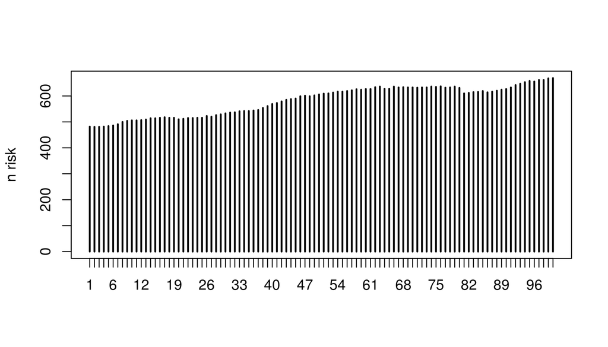

```r
# number of individuals at risk at each time point
plot(table(dsg$X$t), ylab = "n risk")
```

Then we fit the model

```r
glmer_fit <- glmer(Y ~ x + (x | t), family = binomial(), data = dsg$X)
```

The summary of the fit is

```r
summary(glmer_fit)
```

```
## Generalized linear mixed model fit by maximum likelihood (Laplace
##   Approximation) [glmerMod]
##  Family: binomial  ( logit )
## Formula: Y ~ x + (x | t)
##    Data: dsg$X
##
##      AIC      BIC   logLik deviance df.resid
##     3846     3891    -1918     3836    58185
##
## Scaled residuals:
##    Min     1Q Median     3Q    Max
##  -0.35  -0.08  -0.05  -0.03  35.05
##
## Random effects:
##  Groups Name        Variance Std.Dev. Corr
##  t      (Intercept) 0.318    0.564
##         x           0.614    0.784    -0.37
## Number of obs: 58190, groups:  t, 100
##
## Fixed effects:
##             Estimate Std. Error z value Pr(>|z|)
## (Intercept)   -3.600      0.125   -28.9   <2e-16 ***
## x             -2.178      0.181   -12.0   <2e-16 ***
## ---
## Signif. codes:  0 '***' 0.001 '**' 0.01 '*' 0.05 '.' 0.1 ' ' 1
##
## Correlation of Fixed Effects:
##   (Intr)
## x -0.695
```

The estimated covariance matrix is

```r
glmer_vcor <- VarCorr(glmer_fit)
glmer_vcor <-
  diag(attr(glmer_vcor$t, "stddev")) %*% attr(glmer_vcor$t, "correlation") %*%
  diag(attr(glmer_vcor$t, "stddev"))

show_covar <- function(Q){
  cat("Standard deviations\n")
  print(sqrt(diag(Q)))
  cat("Lower correlation matrix\n")
  tmp <- cov2cor(Q)
  print(tmp[-1, -ncol(tmp)])
}
show_covar(glmer_vcor)
```

```
## Standard deviations
## [1] 0.5641 0.7839
## Lower correlation matrix
## [1] -0.3746
```

```r
show_covar(Qmat)
```

```
## Standard deviations
## [1] 0.75 0.75
## Lower correlation matrix
## [1] -0.4
```

The approximate log-likelihood is

```r
logLik(glmer_fit)
```

```
## 'log Lik.' -1918 (df=5)
```

## Particle filter and smoother

We start by using the particle filter and smoother from Fearnhead, Wyncoll, and Tawn (2010)

```r
n_threads <- 6

# you can replace this with e.g.,
#   max(parallel::detectCores(logical = FALSE), 2)))

# control object
dd_ctrl <- PF_control(
    N_fw_n_bw = 500, N_smooth = 2500, N_first = 1000, eps = .0001,
    N_smooth_final = 500,
    method = "PF_normal_approx_w_cloud_mean", est_a_0 = FALSE,
    n_max = 500L, smoother = "Fearnhead_O_N", averaging_start = 100L,
    nu = 6L, covar_fac = 1.1, n_threads = n_threads)
```

```r
set.seed(26564868)
system.time(pf_fearn <- PF_EM(
  Surv(tstart, tstop, y) ~ x + ddFixed(x) + ddFixed_intercept(TRUE), df,
  Q_0 = diag(3^2, 2), Q = diag(1, 2), Fmat = diag(.9, 2),
  by = 1, type = "VAR", model = "logit", max_T = n_periods,
  control = dd_ctrl))
```

```
## a_0 not supplied. IWLS estimates of static glm model is used for random walk models. Otherwise the values are zero
```

```
##    user  system elapsed
## 2724.37   23.89  462.76
```

`system.time` is used to show the computation time. The estimates are

```r
show_covar(pf_fearn$Q)
```

```
## Standard deviations
## (Intercept)           x
##      0.5868      0.7115
## Lower correlation matrix
## [1] -0.3475
```

```r
pf_fearn$F
```

```
##             (Intercept)        x
## (Intercept)    -0.07188  0.11946
## x               0.56780 -0.01151
```

```r
pf_fearn$fixed_effects
```

```
## (Intercept)  ddFixed(x)
##      -3.606      -2.171
```

```r
beta # actual values
```

```
## [1] -4 -2
```

The log-likelihood at each EM iteration is

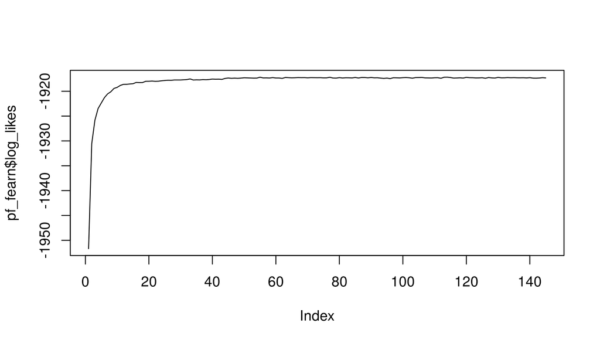

```r
plot(pf_fearn$log_likes, type = "l")
```

```r
logLik(pf_fearn)
```

```
## 'log Lik.' -1917 (df=9)
```

The smoothed estimates and 90% confidence intervals are

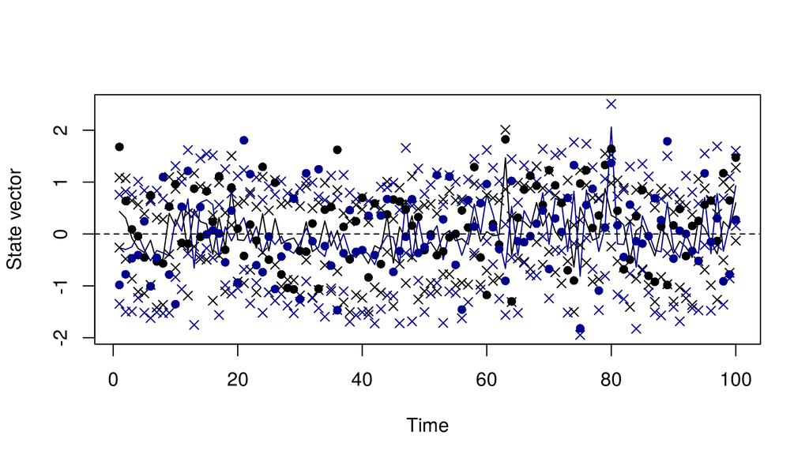

```r
plot(pf_fearn, qlvls = c(.05, .95), col = c("Black", "Darkblue"))
matpoints(t(t(betas) - beta), pch = 16, col = c("Black", "Darkblue"))
abline(h = 0, lty = 2)
```

The crosses are the point-wise confidence bounds, the lines are the smoothed means, and the full dot is the actual value. The effective sample sizes are

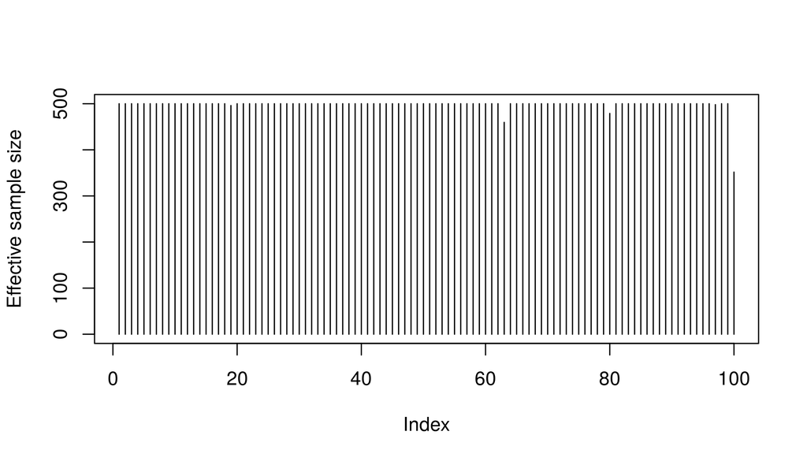

```r
plot(
  pf_fearn$effective_sample_size$smoothed_clouds, type = "h",
  ylab = "Effective sample size",
  ylim = range(pf_fearn$effective_sample_size$smoothed_clouds, 0))
```

We can get an approximation of the final log-likelihood as follows

```r
logLik(PF_forward_filter(pf_fearn, N_fw = 10000, 10000))
```

```
## 'log Lik.' -1917 (df=NA)
```

This is close to the `glmer` result as expected and also does not match as it need not to since we estimate $F$

```r
logLik(glmer_fit)
```

```
## 'log Lik.' -1918 (df=5)
```

We may ask what would happen if we used different starting values. E.g.,

```r
set.seed(92890620)
pf_fearn_other <- PF_EM(
  Surv(tstart, tstop, y) ~ x + ddFixed(x) + ddFixed_intercept(TRUE), df,
  Q_0 = diag(2^2, 2), Q = diag(.1^2, 2), Fmat = diag(.5, 2),
  by = 1, type = "VAR", model = "logit", max_T = n_periods,
  control = dd_ctrl)
```

```
## a_0 not supplied. IWLS estimates of static glm model is used for random walk models. Otherwise the values are zero
```

The estimates are

```r
show_covar(pf_fearn_other$Q)
```

```
## Standard deviations
## (Intercept)           x
##      0.3114      0.4127
## Lower correlation matrix
## [1] 0.8204
```

```r
pf_fearn_other$F
```

```
##             (Intercept)      x
## (Intercept)     -0.2214 0.1135
## x               -1.2216 0.9862
```

The log-likelihood at each of the EM iterations are

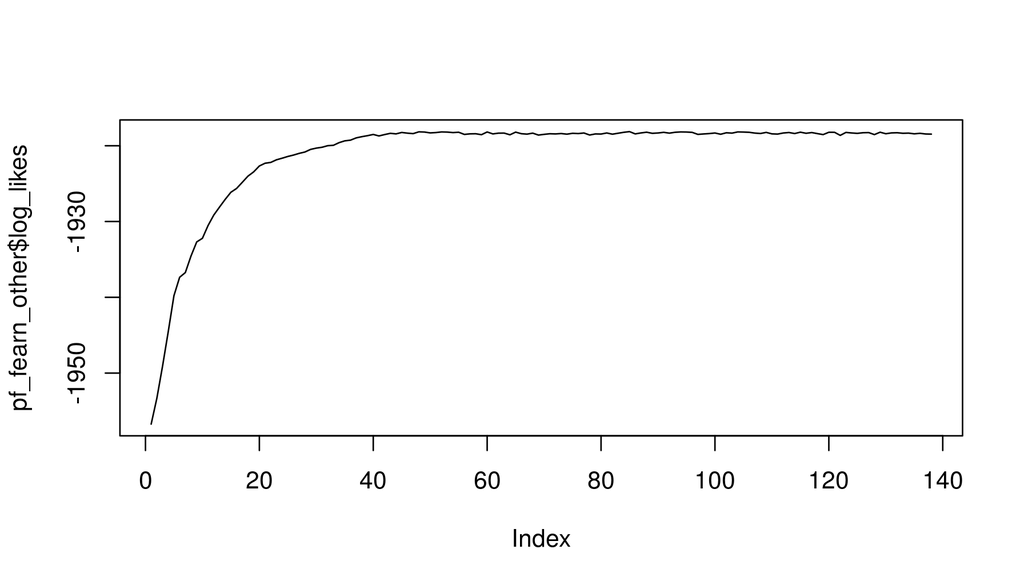

```r
plot(pf_fearn_other$log_likes, type = "l")
```

```r
tail(pf_fearn_other$log_likes, 4)
```

```
## [1] -1918 -1918 -1918 -1918
```

The smoothed estimates are

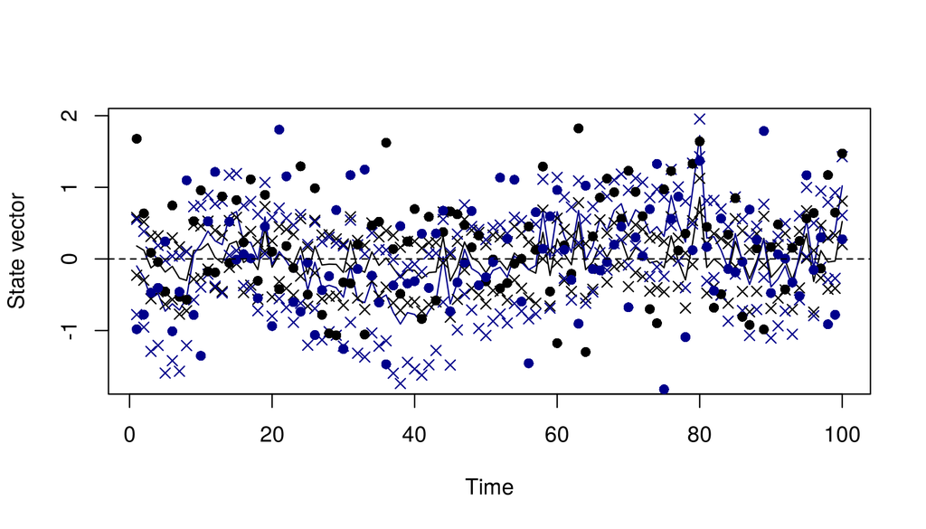

```r
plot(pf_fearn_other, qlvls = c(.05, .95), col = c("Black", "Darkblue"))
matpoints(t(t(betas) - beta), pch = 16, col = c("Black", "Darkblue"))
abline(h = 0, lty = 2)
```

# References

Fearnhead, Paul, David Wyncoll, and Jonathan Tawn. 2010. “A Sequential Smoothing Algorithm with Linear Computational Cost.” *Biometrika* 97 (2). [Oxford University Press, Biometrika Trust]: 447–64. http://www.jstor.org/stable/25734097.